# Machine learning analyses

# Scope

This notebook documents the models used to predict continuous copy number signature activities and signature-derived cluster membership. The preprocessing scripts used to create the final model matrices are documented in `00_data_preprocessing.Rmd`. The analyses start from the final training and test objects. Model implementation followed the recommended workflows provided by the `caret` and Flexynesis packages.

## Target signatures

| Compendium | Signatures |
| --- | --- |
| Drew | CX1, CX2, CX3, CX5 |
| Steele | CN1, CN2, CN9, CN17 |
| Tao | Sig1, Sig2, Sig5, Sig7 |

The same modeling procedure was repeated for each target signature. The individual scripts differed mainly in the loaded input file, target column, saved object name, and output path.

The training blocks are retained as executable templates but are not evaluated when the notebook is rendered because the serialized historical model objects are not distributed. After loading a matrix from `final_matrices.RData` and creating the stratified split documented in `00_data_preprocessing.Rmd`, users can run the relevant block for any target signature.

# R packages

```r
library(caret)
library(kernlab)
library(xgboost)
library(plyr)
library(dplyr)
library(ggplot2)
library(ggpubr)
library(stringr)
```

## Lasso and Ridge example for CX1

```r
lambda1 <- seq(0.0001, 0.01, length = 100)
lambda2<-seq(0,2,length=100)

library(caret)
set.seed(1234)
glmnet_lasso<- train(
  ordi_train[,-c(1,2)], ordi_train$CX1, method = "glmnet",
  trControl = trainControl("cv", number = 10, savePredictions = TRUE),
  tuneGrid = expand.grid(alpha = 1, lambda = lambda1)
)

##glmnet
set.seed(1234)
glmnet_ridge <- train(
  ordi_train[,-c(1,2)], ordi_train$CX1, method = "glmnet",
  trControl = trainControl("cv", number = 10, savePredictions = TRUE),
  tuneGrid = expand.grid(alpha = 0, lambda = lambda2)
)
```

# Support Vector Machine

```r
set.seed(1234)
svm_linear_2 <- train(
  train_data[,-c(1,2)], train_data$CX2, method = "svmLinear",
  trControl = trainControl("cv", number = 10, savePredictions = TRUE, allowParallel = TRUE),
  tuneGrid = expand.grid(C = c(0.000001, 0.00001, 0.00005, 0.0001, 0.001, 0.01, 1))
)

set.seed(1234)
svm_radial_5<- train(
  train_data[,-c(1,2)], train_data$CX5, method = "svmRadialSigma",
  trControl = trainControl("cv", number = 10, savePredictions = TRUE, allowParallel = TRUE),
  tuneGrid = expand.grid(C= c(4, 6, 8, 10, 12, 16), sigma =c(.088365e-05, .411635e-05, .911635e-05, 1.411635e-05, 1.908374e-05, 2.405114e-05))
)
```

# XGBoost

```r
hyperparam_grid <- expand.grid(
  nrounds = seq(from = 1000, to = 1500, by = 75),
  eta = c(0.005,0.01, 0.15),
  max_depth = c(2, 4, 6),
  gamma = c(0),
  colsample_bytree = c(1),
  min_child_weight = c(3, 5),
  subsample = c(0.75)
)

set.seed(1234)
xgb <- train(ordi_train[,-c(1,2)], ordi_train$CX1, method = "xgbTree",
                 trControl = trainControl("cv", number = 10, savePredictions = TRUE,  allowParallel = TRUE),
                 tuneGrid = hyperparam_grid,
                 verbose = TRUE)
```

# performance extraction example

```r
testX<-ordi_test[,-c(1,2)]
predictions <- extractPrediction(
  list(glmnet_lasso),
  testX,
  ordi_test$CX1
)

predictions %>%
  group_by(model, dataType) %>%
  dplyr::summarise(
    rmse = RMSE(pred = pred, obs = obs),
    rsq = R2(pred = pred, obs = obs)
  )
```

# Deep learning with Flexynesis

```python
import os
os.environ["OMP_NUM_THREADS"] = "1"
import flexynesis
import torch
import numpy as np
import seaborn as sns
from sklearn.metrics import mean_absolute_error
import pandas as pd
import math
import requests
import tarfile
import re
import logging
import matplotlib.pyplot as plt
import matplotlib
from sklearn.metrics import balanced_accuracy_score, f1_score, cohen_kappa_score, classification_report
from sklearn.metrics import mean_squared_error
from scipy.stats import linregress

def evaluate_classifier(y_true, y_pred, print_report = False):
    # Balanced accuracy
    balanced_acc = balanced_accuracy_score(y_true, y_pred)
    # F1 score (macro)
    f1 = f1_score(y_true, y_pred, average='macro', zero_division=0)
    # Cohen's Kappa
    kappa = cohen_kappa_score(y_true, y_pred)
    # Full classification report
    if print_report:
        print("\nClassification Report:")
        report = classification_report(y_true, y_pred, zero_division=0)
        print(report)
    return {"balanced_acc": balanced_acc, "f1_score": f1, "kappa": kappa}

def evaluate_regressor(y_true, y_pred):
    mse = mean_squared_error(y_true, y_pred)
    mae = mean_absolute_error(y_true, y_pred)
    slope, intercept, r_value, p_value, std_err = linregress(y_true,y_pred)
    r2 = r_value**2
    return {"mse": mse, "r2": r2, "pearson_corr": r_value, "mae": mae}

def evaluate_survival(outputs, durations, events):
    valid_indices = ~torch.isnan(durations) & ~torch.isnan(events)
    if valid_indices.sum() > 0:
        outputs = outputs[valid_indices]
        events = events[valid_indices]
        durations = durations[valid_indices]
    # Ensure inputs are in the correct format (numpy arrays)
    if isinstance(durations, torch.Tensor):
        durations = durations.numpy()
    if isinstance(events, torch.Tensor):
        events = events.numpy()
    if isinstance(outputs, torch.Tensor):
        outputs = outputs.numpy()

    # Compute the c-index
    # reverse the directionality of risk_scores to make it compatible with lifelines' assumption
    c_index = concordance_index(durations, -outputs, events)
    return {'cindex': c_index}


def evaluate_wrapper(method, y_pred_dict, dataset, surv_event_var = None, surv_time_var = None):
    metrics_list = []
    for var in y_pred_dict.keys():
        if dataset.variable_types[var] == 'numerical':
            if var == surv_event_var:
                events = dataset.ann[surv_event_var]
                durations = dataset.ann[surv_time_var]
                metrics = evaluate_survival(y_pred_dict[var], durations, events)
            else:
                ind = ~torch.isnan(dataset.ann[var])
                metrics = evaluate_regressor(dataset.ann[var][ind], y_pred_dict[var][ind].flatten())
        else:
            ind = ~torch.isnan(dataset.ann[var])
            metrics = evaluate_classifier(dataset.ann[var][ind], y_pred_dict[var][ind])

        for metric, value in metrics.items():
            metrics_list.append({
                'method': method,
                'var': var,
                'variable_type': dataset.variable_types[var],
                'metric': metric,
                'value': value
            })
    # Convert the list of metrics to a DataFrame
    return pd.DataFrame(metrics_list)



torch.set_num_threads(4)
HPO_ITER = 15

data_importer = flexynesis.DataImporter(path ='imptut_folder_path',
                                        data_types = ['exp', 'meth', "mut"],
                                        log_transform=False,
                                        concatenate=False,
                                        top_percentile=75,
                                        min_features=1000,
                                        correlation_threshold=0.8,
                                        variance_threshold=0.5)
train_dataset, test_dataset = data_importer.import_data()

tuner = flexynesis.HyperparameterTuning(dataset = train_dataset,
                                        model_class = flexynesis.DirectPred,
                                        target_variables = ["CX1"],
                                        config_name = "DirectPred",
                                        n_iter=HPO_ITER,  plot_losses=False,
                                        cv_splits= 10,
                                        #device_type= "cuda",
                                        early_stop_patience=10)
model, best_params = tuner.perform_tuning()

print(model)
print(best_params)

y_pred_dict = model.predict(test_dataset)
print(y_pred_dict)

metrics_df = evaluate_wrapper(method = 'DirectPred', y_pred_dict=y_pred_dict, dataset = test_dataset)
print(metrics_df)

metrics_df.to_csv('../Results/name.csv', index = False)
```

# Cluster prediction

The same XGBoost workflow described above was applied to predict binary cluster membership using the final Drew, Steele, and Tao training and test datasets. The outcome variable was Cluster 1 versus Cluster 2.

## Performance extraction

```r
testX<-ordi_test[,-c(1,2)]
predictions <- extractPrediction(
  list(xgb_drew_cluster_2C),
  testX,
  ordi_test$cluster
)

# Split by model and dataType
grouped_preds <- predictions %>%
  group_split(model, dataType)

# Loop over each group and apply confusionMatrix
results <- lapply(grouped_preds, function(df) {
  cm <- confusionMatrix(df$pred, df$obs)
  data.frame(
    model = unique(df$model),
    dataType = unique(df$dataType),
    Accuracy = cm$overall["Accuracy"],
    Kappa = cm$overall["Kappa"],
    F1_score = cm$byClass["F1"]
    # You can also extract class-wise metrics if needed
  )
})

# Combine results
bind_rows(results)
```

# Accuracy by tumor type

The following example generates Figure 8 from the test-set predictions of the binary cluster classifiers. Tumor-specific accuracy is shown for tumor types represented by at least four test samples.

```r
plot_accuracy_per_tumor <- function(grouped_preds, title_suffix = "") {
  results <- data.frame()

  for (df in grouped_preds) {
    mod <- unique(df$model)
    dt <- unique(df$dataType)

    cm_total <- confusionMatrix(df$pred, df$obs)
    acc_total <- cm_total$overall["Accuracy"]
    n_total <- nrow(df)

    results <- rbind(results, data.frame(
      Model = mod,
      DataType = dt,
      Tumor = "Overall",
      Accuracy = acc_total,
      Samples = n_total,
      alpha = 1
    ))

    for (tum in unique(df$cancer_type[!is.na(df$cancer_type)])) {
      df_sub <- df %>% filter(cancer_type == tum)
      n_samples <- nrow(df_sub)
      if (n_samples >= 4) {
        cm_tum <- confusionMatrix(df_sub$pred, df_sub$obs)
        acc_tum <- cm_tum$overall["Accuracy"]

        results <- rbind(results, data.frame(
          Model = mod,
          DataType = dt,
          Tumor = tum,
          Accuracy = acc_tum,
          Samples = n_samples,
          alpha = 0.5
        ))
      }
    }
  }

  results_plot <- results %>% filter(DataType == "Test")

  results_plot$Tumor <- factor(results_plot$Tumor, levels = c(
    "Overall",
    results_plot %>%
      filter(Tumor != "Overall") %>%
      arrange(desc(Accuracy)) %>%
      pull(Tumor)
  ))

  base_color <- "#1f78b4"

  p <- ggplot(
    results_plot,
    aes(x = Tumor, y = Accuracy, fill = base_color, alpha = alpha)
  ) +
    geom_bar(stat = "identity") +
    scale_fill_identity() +
    scale_alpha_identity() +
    labs(
      x = NULL,
      y = "Accuracy"
    ) +
    theme_minimal() +
    theme(axis.text.x = element_text(angle = 45, hjust = 1))

  print(p)
}
```

# extraction example for drews

```r
load("model.RData")

testX <- ordi_test[,-c(1,2)]
predictions_drew <- extractPrediction(
  list(model),
  testX,
  ordi_test$cluster
)

predictions_drew$cancer_type <- NA
test_idx <- which(predictions_drew$dataType == "Test")
if(length(test_idx) == nrow(ordi_test)) {
  predictions_drew$cancer_type[test_idx] <- ordi_test$cancer_type
} else {
  stop("DREWs: Lunghezza non corrisponde!")
}

grouped_preds_drew <- predictions_drew %>%
  group_split(model, dataType)
drew_acc<-plot_accuracy_per_tumor(grouped_preds_drew, "(Drews)")
```

## Test sample counts

```r
get_counts <- function(preds, model_name) {
  test_idx <- which(preds$dataType == "Test")
  tumors <- preds$cancer_type[test_idx]
  counts <- as.data.frame(table(tumors))
  colnames(counts) <- c("Tumor", "Samples")
  counts$Model <- model_name
  counts
}

counts_drew <- get_counts(predictions_drew, "Drews")
counts_steele <- get_counts(predictions_steele, "Steele")
counts_tao <- get_counts(predictions_tao, "Tao")

counts_all <- bind_rows(counts_drew, counts_steele, counts_tao)

mean_counts <- counts_all %>%
  group_by(Tumor) %>%
  summarise(mean_samples = mean(Samples)) %>%
  arrange(desc(mean_samples))

counts_all$Tumor <- factor(
  counts_all$Tumor,
  levels = rev(mean_counts$Tumor)
)

a <- ggplot(
  counts_all,
  aes(x = Samples, y = Tumor, fill = Model, alpha = 0.9)
) +
  geom_bar(stat = "identity", position = "dodge") +
  facet_wrap(~ Model, ncol = 3) +
  labs(
    x = "n° samples",
    y = NULL
  ) +
  theme_minimal() +
  theme(
    strip.text = element_text(face = "bold"),
    axis.text.y = element_text(size = 8)
  ) +
  scale_fill_manual(values = c(
    "Drew" = "#1f78b4",
    "Steele" = "#33a02c",
    "Tao" = "#e31a1c"
  )) +
  guides(alpha = "none")
```

## Figure 8

```r
list_accuracy<-list(drew_acc, steele_acc, tao_acc, a)
ggarrange(plotlist = list_accuracy, labels = "auto")
```

# Figure 9, panel A

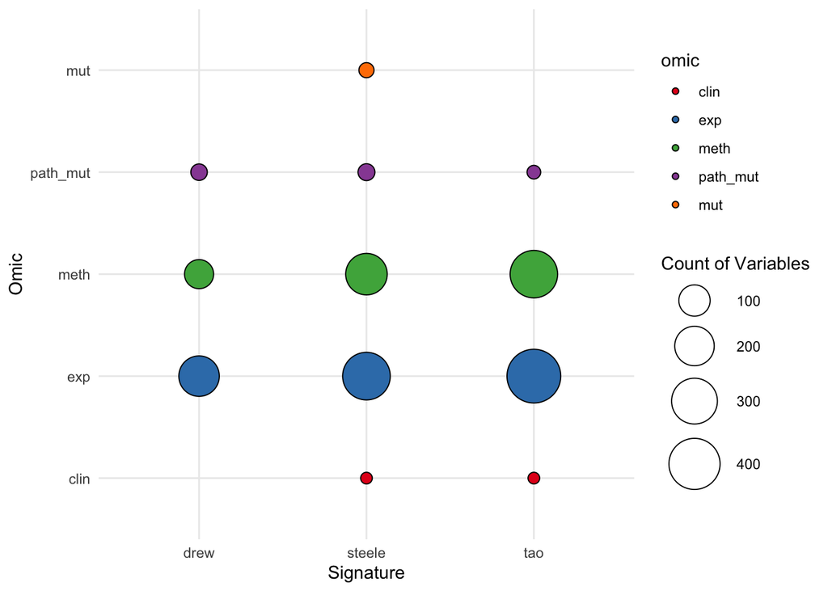

```r
load("../data/processed/list_varImp_class_80perc.RData")

aggregate_varImp <- function(results) {
  combined_df <- data.frame()

  for (signature in names(results)) {
    model_results <- results[[signature]]$top_var_metric
    for (model_nm in names(model_results)) {
      df <- as.data.frame(model_results[[model_nm]])
      df$signature <- signature
      df$class <- stringr::str_extract(model_nm, "class_[0-9]+")
      combined_df <- rbind(combined_df, df)
    }
  }

  names(combined_df)[1] <- "omic"
  combined_df$class <- factor(
    combined_df$class,
    levels = c("class_2", "class_4")
  )
  combined_df %>%
    group_by(omic, signature, class) %>%
    summarise(total_value = sum(Freq), .groups = "drop") %>%
    mutate(
      omic = factor(
        omic,
        levels = c("clin", "exp", "meth", "path_mut", "mut")
      )
    )
}

aggregated_results <- aggregate_varImp(results)

plot_omic_distribution <- function(aggregated_df) {
  aggregated_df <- aggregated_df %>%
    filter(class == "class_2")

  ggplot(
    aggregated_df,
    aes(x = signature, y = omic, size = total_value, fill = omic)
    ) +
    geom_point(shape = 21, color = "black") +
    scale_size_continuous(range = c(3, 15)) +
    labs(
      x = "Signature",
      y = "Omic",
      size = "Count of Variables"
    ) +
    theme_minimal() +
    scale_fill_brewer(palette = "Set1")
}

c<-plot_omic_distribution(aggregated_results)
c
```

# Input and output files

The final repository inputs for this analysis will be the processed `.RData` files containing the final training and test sets for each target signature and the three cluster classifications.